# Trees and Networks / Genetic Data - Tutorial - QMSS 2017

chiara barbieri

10th May 2017

# Working with a matrix of distances, genetic + linguistic

Handle genetic alignments, genetic distance between populations, build trees and networks. Genetic data from GeLaTo (web platform under construction) elaborated from Pemberton et al. 2013 - autosomal microsatellites. http://www.g3journal.org/content/3/5/891

## 1. Import the data

Import the table with the information for the genetic population samples and the genetic data

```r
listaComplete<-read.table("listaComplete.txt",sep="\t", header=T)
rownames(listaComplete)<-listaComplete$populationName
```

Import the matrix of pairwise distances between populations

```r
matGen<-read.csv("PopDistance.csv")
colnames(matGen)<-rownames(matGen)
```

Import the matrix of linguistic distances

```r
matLin<-read.table("DistLangOceania.txt", sep="\t")
colnames(matLin)<-rownames(matLin)
```

Select the genetic populations that match the languages in the matrix

```r
colnames(matLin)->listaPopOceania  #create the object listaPopOceania, the populations in the match
listaOceania<-listaComplete[listaPopOceania,] #subset of the list of genetic populations

matGenOceania<-matGen[which(rownames(matGen)%in%listaPopOceania),which(colnames(matGen)%in%listaPopOceania),]  #subset of the matrix of pairwise genetic distance

matGenOceania<-matGenOceania[listaPopOceania,listaPopOceania] #the two matrices have the populations/languages in the same order
```

# 2. Geographic distances between populations

We want to control for geography in the similarity patterns we will find.

```r
library("fields")
lista<-listaOceania[,c(6,7)]  #select latitude and longitude
rdist.earth (lista, miles=FALSE) ->matGeoOceania
matGeoOceania[upper.tri(matGeoOceania)] <- NA
diag(matGeoOceania) = 0   # the matrix of geographic distances is ready to use
```

where are we on the map?

```r
library('maps')
library('geosphere')
library("rworldmap")
```

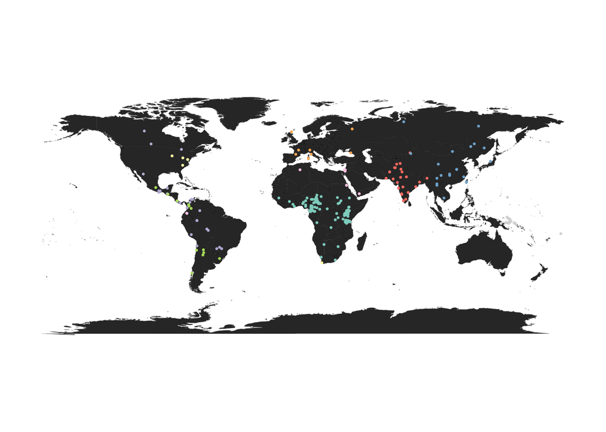

```r
map(database = "world", regions = ".", col="grey20", fill=TRUE,  lwd=0.1)
points(x=listaComplete$lon, y=listaComplete$lat, pch=19,  cex=0.3, col=as.character(listaComplete$colorCode))
```

We create a color code for the language families in our list of populations/languages.

```r
fam<-read.table("LFamiliesOceania.txt", as.is=T, header=T, sep="\t")
rownames(fam)<-fam[,1]
famm<-fam[listaPopOceania,]
families<-table(famm[,3])
colorcod<-rainbow(length(families))
colorstring<-c(rep(NA, length(famm[,3])))

for (i in 1:length(families)) {
  colorstring[which(famm[,3]==labels(families[i]))]<-colorcod[i]
}
```

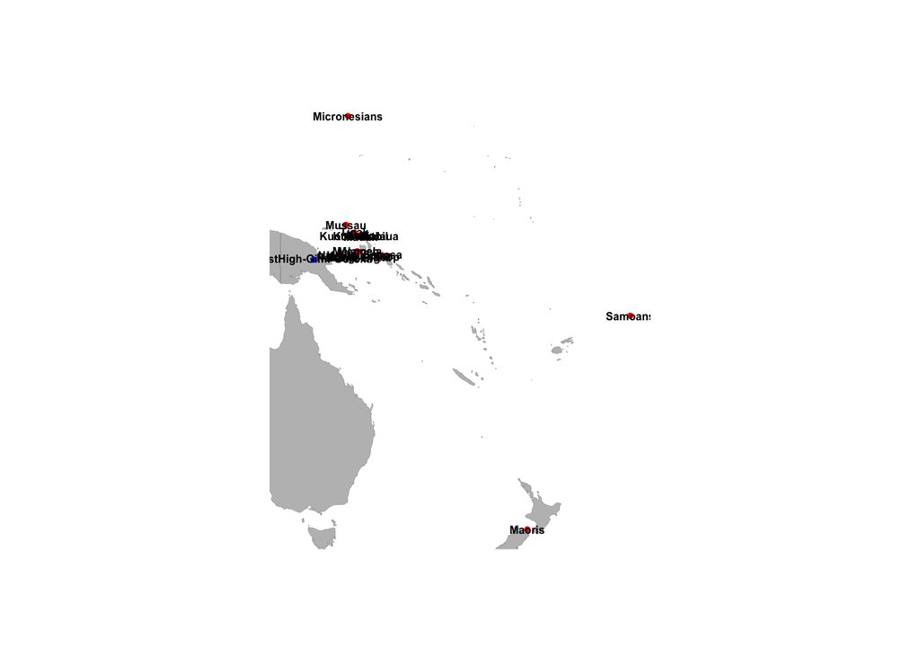

```r
listaOceania<-listaOceania[listaPopOceania,]
map(database = "world", regions = ".", xlim=c(140,190),ylim=c(-43,13),col="grey", fill=TRUE,  lwd=0.1)
points(x=listaOceania$lon, y=listaOceania$lat, pch=19,  cex=0.5, col=colorstring)
text(x=listaOceania$lon, y=listaOceania$lat,labels=listaOceania$populationName,cex=0.5, font=2)
```

# 3. Correlation between distances: Mantel test

The Mantel test is a simple way to assess global patterns of correlations between matrices. Use with moderation.

```r
library("ecodist")
m1<-as.dist(matGenOceania)
m2<-as.dist(matLin)
m3<-as.dist(matGeoOceania)
```

[output not shown]

The partial mantel is also a correlation test between two matrices, but controlling for the effect of a third distance matrix. This control is done by calculating the correlation between the residuals of each of the two main distance matrices after a linear regression on the third distance matrix.

Visualize the distances in a correlation plot

[output not shown]

Which population speak the same language but are genetically distant?

# 4. Visualize relationships with a tree

We create a Neighbour Joining tree from the matrix of pairwise distances.

### UPGMA tree

```r
library("pegas")
library("phangorn")
upgmatreeGen<-upgma(m1)
```

```
plot.phylo(upgmatreeGen,  tip.col=colorstring)
unlist(names(families))->nomilegenda
legend("bottomleft",nomilegenda,text.col=colorcod)

upgmatreeLing<-upgma(m2)
plot.phylo(upgmatreeLing,  tip.col=colorstring)
unlist(names(families))->nomilegenda
legend("bottomleft",nomilegenda,text.col=colorcod)
```

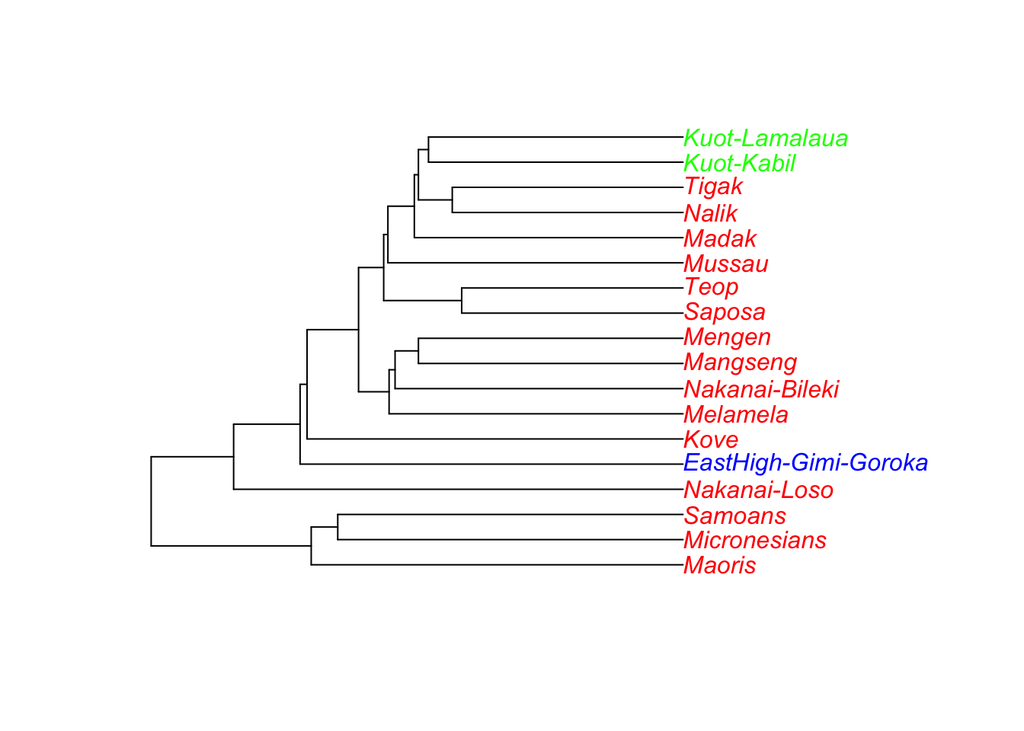

### Neighbour Joining tree

```r
nj.gen <- nj(m1) #create the object neighbour joining tree for genetic distances
nj.gen$edge.length[nj.gen$edge.length < 0] = 0.002 # a little trick to avoid negative branches
```

```
plot.phylo(nj.gen, type="u", tip.col=colorstring, cex=0.3 )
unlist(names(families))->nomilegenda
legend("bottomleft",nomilegenda,text.col=colorcod)

write.tree(nj.gen, "Oceania_distGen.tree")

nj.ling <- nj(m2) #create the object neighbour joining tree for linguistic distances
nj.ling$edge.length[nj.ling$edge.length < 0] = 0.002


plot.phylo(nj.ling, type="u", tip.col=colorstring, cex=0.5 )
unlist(names(families))->nomilegenda
legend("bottomleft",nomilegenda,text.col=colorcod)

write.tree(nj.ling, "Oceania_distLing.tree")
```

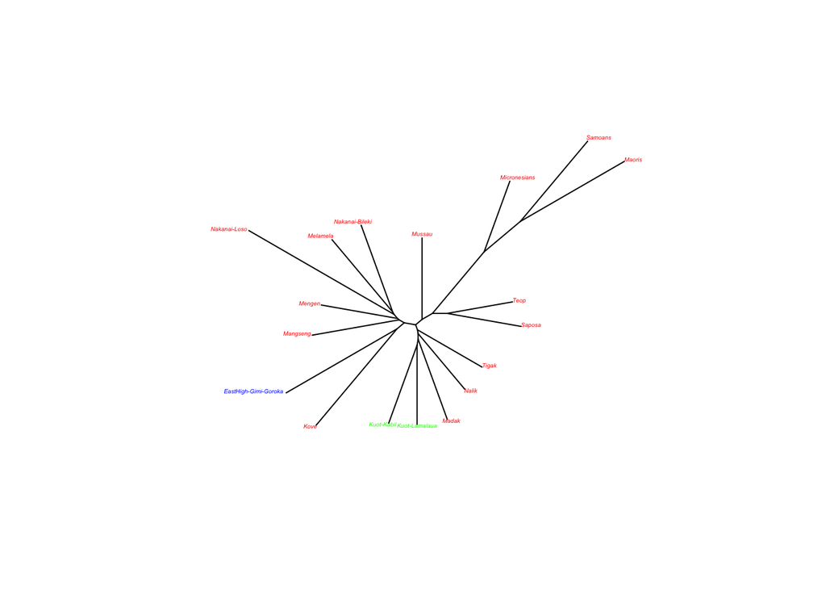

What are the differences between the two trees?

# 5. Visualize relationships with a neighbor net

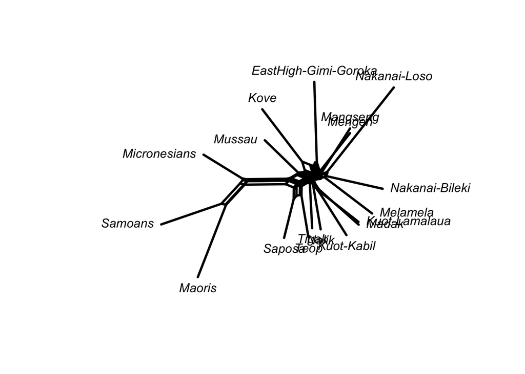

```r
net.Gen<-neighborNet(matGenOceania)
plot(net.Gen, "2D")
```

It’s a bit ugly. Better plotting options in SplitsTree!

*for questions: barbieri.chiara@gmail.com*